# SurveyAnalysis-Correlations

### Survey analysis - Shampoo brands

1. Frequency analysis
2. Correlation
3. Solar correlation plot
4. chi-squared Test
5. Cramers V test
6. Thiels test
7. Correspondence Analysis

### Import libararies & data

```python
import os
import pandas as pd
import numpy as np

import warnings
warnings.filterwarnings('ignore')

# Visualizations
import matplotlib.pyplot as plt
import seaborn as sns

from scipy.stats import chi2_contingency # import Scipy's built-in function

# Analysis
import prince  #pip install prince
```

```python
# Azure data & credentials
from ckpackages import azsql
```

```python
import os
os.getcwd()
```

```python
parent_dir = os.path.abspath(os.pardir)
```

```python
df = pd.read_csv(parent_dir + '\\Data\\Test data.csv',encoding='latin')
```

```python
#data.head()
```

```python
def data_cleaning(dataframe):
    for r in (("\r", ""),("\n", " "),("/"," "),("*","")):
        dataframe.columns = dataframe.columns.str.replace(*r)
        dataframe         = dataframe.apply(lambda x: x.str.replace(*r), axis =1)

    dataframe.drop(dataframe.columns[0], axis=1, inplace =True)
    return dataframe
```

```python
df = data_cleaning(df)
```

```python
# Strip spaces in column headers
df.columns = df.columns.str.strip()
```

```python
df.columns
```

```
Index(['0.2)Gender', '0.3)Age', '0.4)Tag the location', '0.5)Profession',
       'Prime channel',
       '0.7)Which DTH or Cable service do you use?   DTH    ?',
       '0.8)When you want to watch TV what do you generally do ?        ?',
       'Type- spouse', 'Along with spouse', 'Along With kids',
       'What do you do when working',
       '0.12)When do you get time to relax and watch TV          &nbsp;',
       '0.13)When do your children watch TV in weekday weekend        Please note the time',
       '0.14)When do you watch TV&nbsp;along with your spouse', '0.15)',
       '0.16)Which of the above news channels gives more accurate news , according to you&nbsp;&nbsp;   ,',
       '0.17)Name some programs telecasted in this channel',
       '0.18)Please type an answer ..!      ..!', '0.181',
       '0.19)Name some programs telecasted in this channel',
       '0.20)Please type an answer ..!      ..!', '0.201',
       '0.21)Name of the program or Anchors name in the below channels',
       '0.22)', '0.221', '0.23)What hair problems do you have ?     ?',
       '0.24)Which shampoo do you use regularly',
       '0.25)I am using shampoo for my hair problem , if not why ?       ,  ?',
       '0.26)Do you use bottle or sachet', '0.27)Cost of the sachet  Bottle',
       '0.28)Please type your phone number',
       '0.29)What is your email address?', 'Type', 'Prime channel .1', 'Type',
       'Channel 2', 'Channel 2 no.', 'Channel 3', 'Channel 3 no.',
       'Channel 31 no.', 'Channel 32 no.'],
      dtype='object')
```

```python
df1 = df[['0.3)Age','0.2)Gender','0.5)Profession','0.7)Which DTH or Cable service do you use?   DTH    ?','0.8)When you want to watch TV what do you generally do ?        ?','Prime channel .1','Channel 2']]
```

```python
# Enconded table with dummy columns

a0 = pd.get_dummies(df1['0.3)Age'])
a1 = pd.get_dummies(df1['0.2)Gender'])
a2 = pd.get_dummies(df1['0.5)Profession'])
a3 = pd.get_dummies(df1['0.7)Which DTH or Cable service do you use?   DTH    ?']).rename(columns={'Sony':'Sony1'})
a4 = pd.get_dummies(df1['Prime channel .1'])


ds = df1.join(a0).join(a1).join(a2).join(a3).join(a4)
```

### Frequency analysis

```python
data_1.groupby(['Age','Gender','Which is your regular use shampoo1','Who are you still in good touch with ?'])['Response ID'].count()
```

```
Age         Gender  Which is your regular use shampoo1  Who are you still in good touch with ?
-           Female  All clear                           College friends                           1
                    Clinic plus                         College friends                           1
                    Dove                                College friends                           1
                    Others_shampoo                      College friends                           1
                    Pantene                             School friends                            1
                                                                                                 ..
> 55 years  Male    Karthika Shikakai                   Neighbors                                 2
                    Loreal                              Neighbors                                 2
                    Others_shampoo                      Work friends                              1
                    Pantene                             Neighbors                                 1
                    Tresemme                            Neighbors                                 1
Name: Response ID, Length: 433, dtype: int64
```

### Correlation on specific brand data vs whole data

Correlation coefficients

- Between 0.9 and 1.0 - very highly correlated.
- Between 0.7 and 0.9 - highly correlated.
- Between 0.5 and 0.7 - moderately correlated.
- Between 0.3 and 0.5 - low correlation.
- Less than 0.3 - uncertain

#### Specific brand

```python
ds.columns
```

```
Index(['0.3)Age', '0.2)Gender', '0.5)Profession',
       '0.7)Which DTH or Cable service do you use?   DTH    ?',
       'Prime channel .1', '18 to 25', '25 to 35', '35 to 45', '45 to 55',
       '> 55',
       ...
       'Zee telugu ', 'Zee tv', 'discovery', 'fashion channel', 'star movies',
       'star plus', 'star sports', 'v6', 'zee cinema', 'zee telugu'],
      dtype='object', length=113)
```

```python
corr = ds.corr()

df_ci = corr.unstack().sort_values().drop_duplicates().reset_index(name='correlation_index')

df1_ci = df_ci[(df_ci['correlation_index']>0.35) | (df_ci['correlation_index']<-0.35) ]
#df1_ci['Investigation'] = str(brand)

cmap = sns.diverging_palette(0, 230, 90, 60, as_cmap=True)

df1_ci = df1_ci.reset_index(drop=True)


display(df1_ci.style.background_gradient(cmap=cmap))
```

|  | level_0 | level_1 | correlation_index |
| --- | --- | --- | --- |
| 0 | Female | Male | -1.000000 |
| 1 | 18 to 25 | 25 to 35 | -0.545232 |
| 2 | House wife | Male | -0.542614 |
| 3 | 18 to 25 | 35 to 45 | -0.403618 |
| 4 | Survey engineer | Internet | 0.350559 |
| 5 | TV9 | Internet | 0.350559 |
| 6 | Bank employee | Internet | 0.350559 |
| 7 | Internet | Sony TV. | 0.350559 |
| 8 | DD Free Dish | Dont know | 0.370141 |
| 9 | DD Free Dish | Star sports | 0.370141 |
| 10 | Welding | Zee tv | 0.375222 |
| 11 | Marketing | D2h | 0.405782 |
| 12 | Barber | Jio | 0.517150 |
| 13 | Female | House wife | 0.542614 |
| 14 | Etv news | Govt employee | 0.575957 |
| 15 | Jabardast | Barber | 0.575957 |
| 16 | Student | 18 to 25 | 0.590234 |
| 17 | Network marketing | Ntv | 0.706254 |
| 18 | zee cinema | zee cinema | 1.000000 |

#### Whole data

```python
df = data_1

a = df['How do you spend your morning time during Weekdays?'].str.get_dummies(sep=',').rename(columns={'Watch TV ':'WatchTV'})
b = df['Select the responses  Options that match your views?'].str.get_dummies(sep=',')
c = df['Before you go to sleep what you typically do?'].str.get_dummies(sep=',').rename(columns={'Watch TV':'Watch_TV'})
d = df['What do you look for when visiting social media reading newspaper'].str.get_dummies(sep=',').rename(columns={'-':'--'})

a0 = pd.get_dummies(df['Age']).rename(columns={'-':'---'})
a1 = pd.get_dummies(df['Gender'])
a2 = pd.get_dummies(df['Which is the most frequently used payment mode for paying Household items  Electricity bills etc'])
a3 = pd.get_dummies(df['Which type do you use']).rename(columns={'-':'----'})

a4 = pd.get_dummies(df['Which is your regular use shampoo1']).rename(columns={'-':'-----'})


dsg = df.join(a0).join(a1).join(a2).join(a3).join(a4).join(a).join(b).join(c).join(d)

# get correlations

ds1 = dsg[dsg.columns[~dsg.columns.isin(['Response ID', 'Age', 'Gender',
   'Before you go to sleep what you typically do?',
   'Brand and shade of hair color', 'Do you use hair dye  Hair color',
   'How do you spend your morning time during Weekdays?',
   'In my opinion, imported products',
   'Please list any two recently watched advertisement Mention the brand name of the Adv',
   'Select the responses  Options that match your views?',
   'What do you look for when visiting social media reading newspaper',
   'What is your opinion on home made remedies?',
   'What would you like to do in your free time',
   'When you listen to music',
   'Which is the most frequently used payment mode for paying Household items  Electricity bills etc',
   'Which is your regular use shampoo',
   'Which of the following you think influences people the most?',
   'Which type do you use', 'Who are you still in good touch with ?',
   'Which is your regular use shampoo1', '-','--','---','----','-----','Please list any two recently watched advertisement (Mention the brand name of the Adv)'])]]


corr1 = ds1.corr()

df_ci = corr1.unstack().sort_values().drop_duplicates().reset_index(name='correlation_index')


df1_ci = df_ci

cmap = sns.diverging_palette(0, 230, 90, 60, as_cmap=True)

df1_ci = df1_ci.reset_index(drop=True)

display(df1_ci.style.background_gradient(cmap=cmap))

#df1_ci.to_csv('all_cp_corr.csv')
```

[output not shown]

```python
def corr_status(df):
    # create a list of our conditions
    conditions = [
        (df['correlation_index'].abs()>=0.9),
        (df['correlation_index'].abs()>=0.7) & (df['correlation_index'].abs()<0.9),
        (df['correlation_index'].abs()>=0.5) & (df['correlation_index'].abs()<0.7),
        (df['correlation_index'].abs()>=0.3) & (df['correlation_index'].abs()<0.5),
        (df['correlation_index'].abs()<0.3),
        ]

    # create a list of the values we want to assign for each condition
    values = ['very highly correlated', 'highly correlated','moderately correlated','low correlation','uncertain']

    # create a new column and use np.select to assign values to it using our lists as arguments
    df['correlation_status'] = np.select(conditions, values)

    return df
```

```python
df_cs = corr_status(df1_ci)

corr_list = ['low correlation','moderately correlated','very highly correlated']
df_cs = df_cs[df_cs['correlation_status'].isin(corr_list)]

cmap = sns.diverging_palette(0, 230, 90, 60, as_cmap=True)

display(df_cs.style.background_gradient(cmap=cmap))
```

|  | level_0 | level_1 | correlation_index | correlation_status |
| --- | --- | --- | --- | --- |
| 0 | Female | Male | -1.000000 | very highly correlated |
| 1 | Sachet | Bottle | -0.982700 | very highly correlated |
| 2 | Apps like- Gpay Paytm | Pay Cash | -0.696377 | moderately correlated |
| 3 | 25 - 40 years | 18 -24 years | -0.574042 | moderately correlated |
| 4 | Male | Read recipes | -0.407252 | low correlation |
| 5 | Browsing phone apps FIT | Read Newspaper | -0.392543 | low correlation |
| 6 | Credit debit card | Pay Cash | -0.387966 | low correlation |
| 7 | Browsing phone apps FIT | I do exercise | -0.379195 | low correlation |
| 8 | Female | Sports News | -0.370409 | low correlation |
| 9 | Male | Finish house hold work | -0.363342 | low correlation |
| 10 | 41 to 55 years | 25 - 40 years | -0.337039 | low correlation |
| 11 | Browsing phone apps FIT | Watch TV | -0.335376 | low correlation |
| 12 | Browsing phone apps FIT | I am always at a rush to go work | -0.322364 | low correlation |
| 1942 | When I buy stuff from Amazon Flipkart I see the reviews as well | OTT platform is one of my favorite | 0.304212 | low correlation |
| 1943 | Read recipes | Spend time with family | 0.331594 | low correlation |
| 1944 | When I buy stuff from Amazon Flipkart I see the reviews as well | Browsing phone apps FIT | 0.351777 | low correlation |
| 1945 | Finish house hold work | Female | 0.363342 | low correlation |
| 1946 | Male | Sports News | 0.370409 | low correlation |
| 1947 | Read recipes | Female | 0.407252 | low correlation |
| 1948 | Browsing phone apps FIT | Browsing phone (apps) | 0.409257 | low correlation |
| 1949 | Finish house hold work | Spend time with family | 0.409656 | low correlation |
| 1950 | Read recipes | Finish house hold work | 0.425693 | low correlation |
| 1951 | 18 -24 years | 18 -24 years | 1.000000 | very highly correlated |

```python
def percent_contribution_column(df,columnname):
    oplist = df[columnname]

    # Value counts
    dfc = oplist.value_counts().reset_index(name='count')
    #.sort_index() to sort

    # Percentage of Value counts
    dfp = (oplist.value_counts()/len(oplist.index)).mul(100).reset_index(name='percent')

    display(dfp)
```

```python
percent_contribution_column(df1_ci,'correlation_status')
```

|  | index | percent |
| --- | --- | --- |
| 0 | uncertain | 98.821721 |
| 1 | low correlation | 0.922131 |
| 2 | very highly correlated | 0.153689 |
| 3 | moderately correlated | 0.102459 |

### Data - Correlation

```python
df = data_1

a = df['How do you spend your morning time during Weekdays?'].str.get_dummies(sep=',').rename(columns={'Watch TV ':'WatchTV'})
b = df['Select the responses  Options that match your views?'].str.get_dummies(sep=',')
c = df['Before you go to sleep what you typically do?'].str.get_dummies(sep=',').rename(columns={'Watch TV':'Watch_TV'})
d = df['What do you look for when visiting social media reading newspaper'].str.get_dummies(sep=',').rename(columns={'-':'--'})

a0 = pd.get_dummies(df['Age']).rename(columns={'-':'---'})
a1 = pd.get_dummies(df['Gender'])
a2 = pd.get_dummies(df['Which is the most frequently used payment mode for paying Household items  Electricity bills etc'])
a3 = pd.get_dummies(df['Which type do you use']).rename(columns={'-':'----'})


a4 = pd.get_dummies(df['Which is your regular use shampoo1']).rename(columns={'-':'-----'})


ds = df.join(a0).join(a1).join(a2).join(a3).join(a4).join(a).join(b).join(c).join(d)

# get correlations
#ds = ds[(ds['Which is your regular use shampoo'].isin(shbrand))]


ds1 = ds[ds.columns[~ds.columns.isin(['Response ID', 'Age', 'Gender',
   'Before you go to sleep what you typically do?',
   'Brand and shade of hair color', 'Do you use hair dye  Hair color',
   'How do you spend your morning time during Weekdays?',
   'In my opinion, imported products',
   'Please list any two recently watched advertisement Mention the brand name of the Adv',
   'Select the responses  Options that match your views?',
   'What do you look for when visiting social media reading newspaper',
   'What is your opinion on home made remedies?',
   'What would you like to do in your free time',
   'When you listen to music',
   'Which is the most frequently used payment mode for paying Household items  Electricity bills etc',
   'Which is your regular use shampoo',
   'Which of the following you think influences people the most?',
   'Which type do you use', 'Who are you still in good touch with ?',
   'Which is your regular use shampoo1','-','--','---','----','-----'])]]

corr = ds1.corr()
```

[output not shown]

63 rows × 63 columns

### Correlation

```python
# Get equal spacing
def get_angles(orbit, number_of_datapoints, ax):
    start = (-2 * math.pi) / 20 * (orbit - 1)
    stop = start + (math.pi / 0.5)
    if orbit > 0:
        ax.text(0, orbit - 0.1, "{0:.1f}".format(1 - float(orbit) / 10), verticalalignment="top",
                horizontalalignment="center", color="black")
    return np.linspace(start, stop, number_of_datapoints, endpoint=True)
```

```python
# Load libraries
import math
import matplotlib.pyplot as plt
import numpy as np
import sys
import csv
import warnings
import argparse

warnings.filterwarnings("ignore")


def get_angles(orbit, number_of_datapoints, ax):
    start = (2 * math.pi) / 11 * (orbit - 1)
    stop = start + (math.pi / 2)
    if orbit > 0:
        ax.text(0, orbit - 0.1, "{0:.1f}".format(1 - float(orbit) / 10), verticalalignment="top",
                horizontalalignment="center", color="black")
    return np.linspace(start, stop, number_of_datapoints, endpoint=True)


def get_y(angle, radius):
    return math.sin(angle) * radius


def get_x(angle, radius):
    return math.cos(angle) * radius


def label_to_idx(labels, label):
    center_idx_bool = labels == label
    return np.asscalar(np.where(center_idx_bool)[0]), center_idx_bool


def transform_to_correlation_dist(data):
    y_corr = np.corrcoef(data.T)

    # we just need the magnitude of the correlation and don't care whether it's positive or not
    abs_corr = np.abs(y_corr)
    return np.nan_to_num(abs_corr)
```

```python
def transform_to_positive_corrs(data, sun_idx):
    y_corr = np.corrcoef(data.T)
    positive = y_corr[sun_idx]
    positive = positive <= 0
    return positive


def solar_corr(data, labels, center, orbits=10,show_window=True):

    display(data[['Clinic plus']].sort_values(by='Clinic plus',ascending=False))

    df_ci = data.unstack().sort_values().drop_duplicates().reset_index(name='correlation_index')
    c1 = "'" + str(center) + "'"

    df1_ci = df_ci
    df1_ci = df1_ci[df1_ci['level_0'].str.contains('Clinic plus') | df1_ci['level_1'].str.contains('Clinic plus')]


    df1_ci['Investigation'] = str('Chik')

    cmap = sns.diverging_palette(0, 230, 90, 60, as_cmap=True)
    df1_ci = df1_ci.reset_index(drop=True)
    display(df1_ci.style.background_gradient(cmap=cmap))


    labels = np.array(labels)
    center_idx, center_idx_bool = label_to_idx(labels, center)
    plot_idx = 23
    all_idx = np.logical_not(center_idx_bool)
    positive = transform_to_positive_corrs(data, center_idx)
    corr_dist = transform_to_correlation_dist(data)

    sun_corr_dist = corr_dist[center_idx]
    colors = np.linspace(0, 1, num=len(sun_corr_dist))
    cordinate_to_correlation = {}
    step = 1.0 / orbits
    last_orbit = 0.1
    fig = plt.gcf()
    fig.set_size_inches(20, 20)
    labels_idx = np.array([center_idx])


    color_map = plt.get_cmap("Paired")
    color_map_circle = plt.get_cmap("RdPu")

    ax = fig.add_subplot(111)
    ax.xaxis.set_visible(False)
    ax.yaxis.set_visible(False)
    ax.set_position([0.01, 0.01, 0.98, 0.98])  # set a new position

    # place sun:
    plt.scatter(0, 0, color=color_map(colors[center_idx]), s=600, label=labels[center_idx])
    col_sun = "#03C03C" if positive[center_idx] else "#FF6961"
    ax.text(0.2, 0.2, str(labels[center_idx]), verticalalignment="bottom", horizontalalignment='left', color=col_sun)

#    ax.text(0.2, 0.2, str(labels[center_idx]), verticalalignment="bottom", horizontalalignment='left', color="gray")

    for orbit in range(1, orbits + 1):
        new_orbit = step * orbit + 0.1
        idx = (sun_corr_dist >= (1 - last_orbit)) & (sun_corr_dist > (1 - new_orbit)) & all_idx
        idx_int = np.where(idx)[0]

        corr_dists = []
        for index in idx_int:
            corr_dists = np.append(corr_dists, corr_dist[center_idx][index])
        sort_args = np.argsort(corr_dists)
        idx_int = idx_int[sort_args]

        labels_idx = np.append(labels_idx, idx_int)
        planets = sum(idx)
        angles = get_angles(orbit, planets, ax)

        # place planets
        while np.any(idx):
            remaining = sum(idx)
            current_planet = planets - remaining
            current_idx = idx_int[current_planet]
            angle = angles[current_planet]
            x = get_x(angle, orbit)
            y = get_y(angle, orbit)
            color = colors[current_idx]
            plt.scatter(x, y, color=color_map(color), s=250, label=labels[current_idx])
            cordinate_to_correlation[(x, y)] = {"is_planet": True, "corr_sun": corr_dist[center_idx, current_idx] }

            planet_idx = current_idx

            idx[planet_idx] = False
            all_idx[planet_idx] = False

            planet_corr = corr_dist[planet_idx]


            ax.text(x-0.35, y+0.2, "{0:.3f}".format(planet_corr[center_idx]))
            col = "#03C03C" if positive[planet_idx] else "#FF6961"
            if orbit == orbits:
                col = "grey"
            ax.text(x + 0.15, y + 0.15, str(labels[planet_idx]),wrap=True,verticalalignment="bottom", horizontalalignment='left',
                    color=col)
            moon_idx = (planet_corr >= 0.8) & all_idx
            moon_idx_int = np.where(moon_idx)[0]
            moons = sum(moon_idx)
            moon_angles = get_angles(0, moons, ax)

            # add orbit around planet if it has moons
            if np.any(moon_idx):
                moon_orbit = 0.5
                circle = plt.Circle((x, y), moon_orbit, color='lightgrey', alpha=0.8, fill=True, zorder=0)
                fig.gca().add_artist(circle)

            while np.any(moon_idx):
                remaining_moons = sum(moon_idx)
                current_moon = moons - remaining_moons
                current_moon_idx = moon_idx_int[current_moon]
                angle = moon_angles[current_moon]
                m_x = get_x(angle, moon_orbit) + x
                m_y = get_y(angle, moon_orbit) + y
                color = colors[current_moon_idx]
                plt.scatter(m_x, m_y, color=color_map(color), s=100, label=labels[current_moon_idx])
                cordinate_to_correlation[(m_x, m_y)] = {"is_planet": False, "corr_sun": corr_dist[center_idx][current_moon_idx]}
                col = "#03C03C" if positive[current_moon_idx] else "#FF6961"
                if orbit == orbits:
                    col = "grey"
                ax.text(m_x + 0.15, m_y + 0.05, str(labels[current_moon_idx]), verticalalignment="bottom",
                        horizontalalignment='left', color=col)
                moon_idx[current_moon_idx] = False
                idx[current_moon_idx] = False
                all_idx[current_moon_idx] = False

        last_orbit = new_orbit

        circle = plt.Circle((0, 0), orbit, color=color_map_circle(1 - ((orbit - 1) * step)), fill=False, zorder=0)
        fig.gca().add_artist(circle)

    labels_pos = np.array(labels)[labels_idx]
    recs = []

    ax = plt.gca()

    ax.axis("equal")
    plt.axis([-20, 25, -15, 15])
    #title = 'Correlation'
    #plt.suptitle(title, fontsize=16)

    plt.subplots_adjust(top=0.95)
#    if save_png:
#        plt.savefig(image_path)

    if show_window:
        # only require mplcursors if we need an interactive plot
        import mplcursors
        #cooordinate_to_correlation[(sel.target.x, sel.target.y)]["corr_sun"])
        cursors = mplcursors.cursor(hover=True)
        @cursors.connect("add")
        def _(sel):
            sel.annotation.set(position=(15, -15))
            # Note: Needs to be set separately due to matplotlib/matplotlib#8956.
            sel.annotation.get_bbox_patch().set(fc="lightgrey")
            sel.annotation.arrow_patch.set(arrowstyle="simple", fc="white", alpha=0)
            sel.annotation.set_text("Correlation to sun \n{}".format(cordinate_to_correlation[ (sel.target[0],sel.target[1])]["corr_sun"]))


        plt.show()
```

```python
def main(d, sun):
    # Load data
    data = d
    labels = data.columns
    solar_corr(data, labels, sun)
```

```python
#!pip install mplcursors
```

### Solar correlation plot

```python
ds1
```

|  | 18 -24 years | 25 - 40 years | 41 to 55 years | < 18 | > 55 years | Female | Male | Apps like- Gpay Paytm | Credit debit card | Net Banking | ... | Reading books | Spend time with family | Watch_TV | Economics News | Local news | Movies Actors Gossips | Read horoscope | Read recipes | Sales News | Sports News |
| --- | --- | --- | --- | --- | --- | --- | --- | --- | --- | --- | --- | --- | --- | --- | --- | --- | --- | --- | --- | --- | --- |
| 0 | 0 | 1 | 0 | 0 | 0 | 0 | 1 | 0 | 0 | 0 | ... | 0 | 0 | 0 | 0 | 0 | 0 | 0 | 0 | 0 | 1 |
| 1 | 1 | 0 | 0 | 0 | 0 | 1 | 0 | 0 | 0 | 0 | ... | 0 | 0 | 1 | 0 | 1 | 0 | 0 | 0 | 0 | 0 |
| 2 | 0 | 1 | 0 | 0 | 0 | 1 | 0 | 0 | 0 | 0 | ... | 0 | 1 | 0 | 1 | 1 | 1 | 0 | 0 | 0 | 0 |
| 3 | 1 | 0 | 0 | 0 | 0 | 1 | 0 | 0 | 0 | 0 | ... | 0 | 0 | 0 | 0 | 0 | 0 | 0 | 0 | 0 | 1 |
| 4 | 0 | 0 | 1 | 0 | 0 | 1 | 0 | 0 | 0 | 0 | ... | 0 | 0 | 0 | 0 | 0 | 0 | 1 | 0 | 0 | 0 |
| ... | ... | ... | ... | ... | ... | ... | ... | ... | ... | ... | ... | ... | ... | ... | ... | ... | ... | ... | ... | ... | ... |
| 1173 | 1 | 0 | 0 | 0 | 0 | 1 | 0 | 0 | 0 | 0 | ... | 0 | 0 | 1 | 0 | 1 | 0 | 0 | 0 | 0 | 0 |
| 1174 | 0 | 1 | 0 | 0 | 0 | 0 | 1 | 1 | 0 | 0 | ... | 0 | 0 | 0 | 0 | 1 | 1 | 0 | 0 | 0 | 0 |
| 1175 | 0 | 1 | 0 | 0 | 0 | 0 | 1 | 0 | 0 | 0 | ... | 0 | 0 | 0 | 0 | 0 | 1 | 0 | 0 | 0 | 0 |
| 1176 | 1 | 0 | 0 | 0 | 0 | 0 | 1 | 0 | 0 | 0 | ... | 0 | 0 | 0 | 1 | 1 | 0 | 0 | 0 | 0 | 0 |
| 1177 | 0 | 1 | 0 | 0 | 0 | 1 | 0 | 1 | 0 | 0 | ... | 0 | 1 | 0 | 1 | 1 | 1 | 0 | 1 | 1 | 0 |

1178 rows × 63 columns

```python
corr1['Clinic plus'].head(20)
```

```
18 -24 years             0.034557
25 - 40 years           -0.068140
41 to 55 years           0.032543
< 18                     0.042063
> 55 years              -0.017888
Female                  -0.189587
Male                     0.189587
Apps like- Gpay Paytm   -0.001246
Credit debit card       -0.067176
Net Banking             -0.043892
Pay Cash                 0.063526
Bottle                  -0.168405
Sachet                   0.172727
All clear               -0.110037
Biotique                -0.057988
Chik                    -0.115808
Clinic plus              1.000000
Dove                    -0.170961
Head and shoulder       -0.178834
Home made               -0.052555
Name: Clinic plus, dtype: float64
```

```python
display(corr1[['Chik']].sort_values(by='Chik',ascending=False))
```

|  | Chik |
| --- | --- |
| Chik | 1.000000 |
| Sachet | 0.121765 |
| < 18 | 0.119584 |
| Male | 0.050786 |
| Watch_TV | 0.043020 |
| ... | ... |
| Finish house hold work | -0.092285 |
| Clinic plus | -0.115808 |
| Bottle | -0.117262 |
| Local news | -0.119278 |
| When I buy stuff from Amazon Flipkart I see the reviews as well | -0.138258 |

63 rows × 1 columns

|  | Clinic plus |
| --- | --- |
| Clinic plus | 1.000000 |
| Male | 0.189587 |
| Sachet | 0.172727 |
| Sports News | 0.082204 |
| Watch_TV | 0.070630 |
| ... | ... |
| Sunsilk | -0.145955 |
| Bottle | -0.168405 |
| Dove | -0.170961 |
| Head and shoulder | -0.178834 |
| Female | -0.189587 |

63 rows × 1 columns

|  | level_0 | level_1 | correlation_index | Investigation |
| --- | --- | --- | --- | --- |
| 0 | Female | Clinic plus | -0.189587 | Chik |
| 1 | Head and shoulder | Clinic plus | -0.178834 | Chik |
| 2 | Clinic plus | Dove | -0.170961 | Chik |
| 3 | Bottle | Clinic plus | -0.168405 | Chik |
| 4 | Clinic plus | Sunsilk | -0.145955 | Chik |
| 5 | Others_shampoo | Clinic plus | -0.124960 | Chik |
| 6 | Clinic plus | Read recipes | -0.123645 | Chik |
| 7 | Clinic plus | Finish house hold work | -0.119952 | Chik |
| 8 | Chik | Clinic plus | -0.115808 | Chik |
| 9 | Clinic plus | All clear | -0.110037 | Chik |
| 10 | Clinic plus | Loreal | -0.106052 | Chik |
| 11 | Tresemme | Clinic plus | -0.105037 | Chik |
| 12 | Clinic plus | Meera | -0.105037 | Chik |
| 13 | Clinic plus | Pantene | -0.105037 | Chik |
| 14 | I wish Youtube give skip ad option even for shorter ads | Clinic plus | -0.091903 | Chik |
| 15 | Karthika Shikakai | Clinic plus | -0.087492 | Chik |
| 16 | Clinic plus | When I buy stuff from Amazon Flipkart I see the reviews as well | -0.084888 | Chik |
| 17 | Meera Shikakai | Clinic plus | -0.083857 | Chik |
| 18 | Clinic plus | Sales News | -0.079497 | Chik |
| 19 | Clinic plus | Spend time with family | -0.070039 | Chik |
| 20 | I do exercise | Clinic plus | -0.068180 | Chik |
| 21 | Clinic plus | 25 - 40 years | -0.068140 | Chik |
| 22 | Clinic plus | Nyle | -0.067624 | Chik |
| 23 | Credit debit card | Clinic plus | -0.067176 | Chik |
| 24 | Clinic plus | Karthika shampoo | -0.064561 | Chik |
| 25 | Clinic plus | Local news | -0.063380 | Chik |
| 26 | Biotique | Clinic plus | -0.057988 | Chik |
| 27 | Indulekha | Clinic plus | -0.056232 | Chik |
| 28 | Recommendation from my friends Family is more believable | Clinic plus | -0.052930 | Chik |
| 29 | Home made | Clinic plus | -0.052555 | Chik |
| 30 | Economics News | Clinic plus | -0.049981 | Chik |
| 31 | Net Banking | Clinic plus | -0.043892 | Chik |
| 32 | Clinic plus | Reading books | -0.041651 | Chik |
| 33 | I see lot of advertisement banners in front of shops | Clinic plus | -0.038802 | Chik |
| 34 | Browsing phone (apps) | Clinic plus | -0.038154 | Chik |
| 35 | Read Newspaper | Clinic plus | -0.037613 | Chik |
| 36 | Clinic plus | Read horoscope | -0.032761 | Chik |
| 37 | Clinic plus | Helping children with school work | -0.032611 | Chik |
| 38 | Clinic plus | I buy things based on shopkeeper's recommendations | -0.029353 | Chik |
| 39 | Clinic plus | Getting kids ready for school | -0.027392 | Chik |
| 40 | Tending to domestic animals | Clinic plus | -0.019904 | Chik |
| 41 | Clinic plus | > 55 years | -0.017888 | Chik |
| 42 | Clinic plus | Ads in TV are more believable than the ads in mobile internet | -0.014902 | Chik |
| 43 | Browsing phone apps FIT | Clinic plus | -0.013964 | Chik |
| 44 | Information in the new paper is not useful it is cluttered | Clinic plus | -0.010840 | Chik |
| 45 | Farm work | Clinic plus | -0.010743 | Chik |
| 46 | Clinic plus | OTT platform is one of my favorite | -0.010738 | Chik |
| 47 | Clinic plus | Office work | -0.005615 | Chik |
| 48 | Clinic plus | Movies Actors Gossips | -0.002853 | Chik |
| 49 | Apps like- Gpay Paytm | Clinic plus | -0.001246 | Chik |
| 50 | I am always at a rush to go work | Clinic plus | 0.013779 | Chik |
| 51 | 41 to 55 years | Clinic plus | 0.032543 | Chik |
| 52 | Clinic plus | Watch TV | 0.033901 | Chik |
| 53 | Clinic plus | 18 -24 years | 0.034557 | Chik |
| 54 | Clinic plus | < 18 | 0.042063 | Chik |
| 55 | Clinic plus | Listen to radio | 0.046491 | Chik |
| 56 | Memes is the easiest method to make fun | Clinic plus | 0.049523 | Chik |
| 57 | Clinic plus | Pay Cash | 0.063526 | Chik |
| 58 | Watch_TV | Clinic plus | 0.070630 | Chik |
| 59 | Sports News | Clinic plus | 0.082204 | Chik |
| 60 | Clinic plus | Sachet | 0.172727 | Chik |
| 61 | Male | Clinic plus | 0.189587 | Chik |

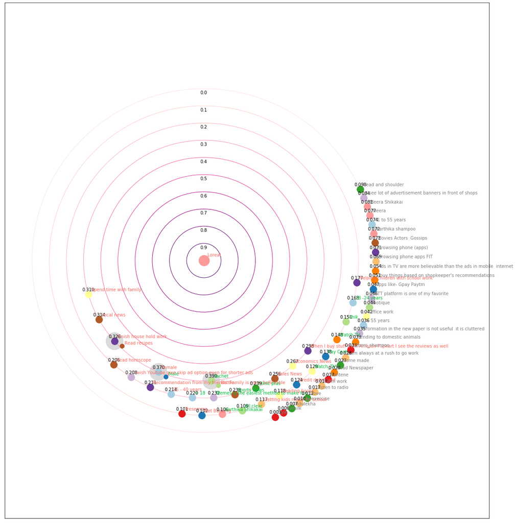

```python
main(corr1,'Loreal')
```

[output not shown]

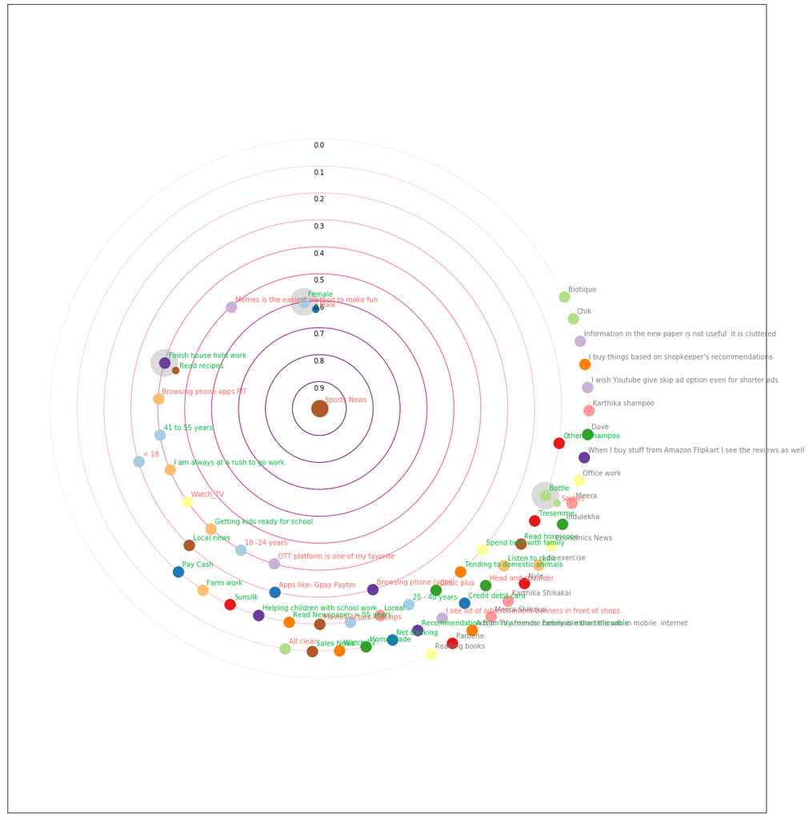

```python
main(corr,'Sports News')
```

### chi-squared Test

- Question 1 - Is there any statistically significant relation between Shampoo Brand Type and Payment mode ?
- Null Hypothesis H0 = Shampoo Brand and Payment mode are independent from each other.
- Alternative Hypothesis HA = Shampoo Brand and Payment mode are not independent of each other. There is a relationship between them.
- Shampoo Brand - categorical variable
- Payment mode - categorical variable

Now, to determine if there is a statistically significant correlation between the variables, we use a chi-square test of independence of variables in a contingency table

Here, we create a contingency table, with the frequencies of all possible values

```python
# Contingency table
ct = pd.crosstab(data_1['Which is your regular use shampoo1'], data_1['Which is the most frequently used payment mode for paying Household items  Electricity bills etc'])
```

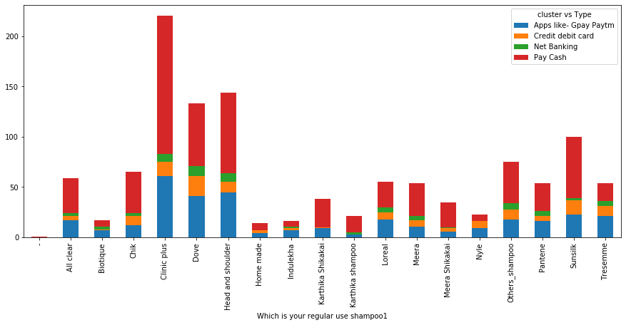

```python
ct.plot.bar(figsize = (15, 6), stacked=True)
plt.legend(title='cluster vs Type')
plt.show()
```

Finally, compute the chi-square test statistic and the associated p-value.

The null hypothesis is the independence between the variables.

SciPy implements this test in scipy.stats.chi2_contingency, which returns several objects. The second result is the p-value.

```python
tstat_scipy,pval_scipy,ddof_scipy,exp_scipy=chi2_contingency(ct, correction=False) # "correction=False" means no Yates' correction is used!
print("Chi-squared test statistic without Yates correction (Scipy): " + str(tstat_scipy))
print("P-value without Yates correction (Scipy): " + str(pval_scipy))
```

[output not shown]

Question 2 - Is there any statistically significant relation between Shampoo Brand Type and Age group ?

- Null Hypothesis H0 = Shampoo Brand and Age group are independent from each other.
- Alternative Hypothesis HA = Shampoo Brand and Age group are not independent of each other. There is a relationship between them.
- Shampoo Brand - categorical variable
- Age group - categorical variable

Now, to determine if there is a statistically significant correlation between the variables, we use a chi-square test of independence of variables in a contingency table

Here, we create a contingency table, with the frequencies of all possible values

```python
# Contingency table
ct = pd.crosstab(data_1['Which is your regular use shampoo1'], data_1['Age'])
```

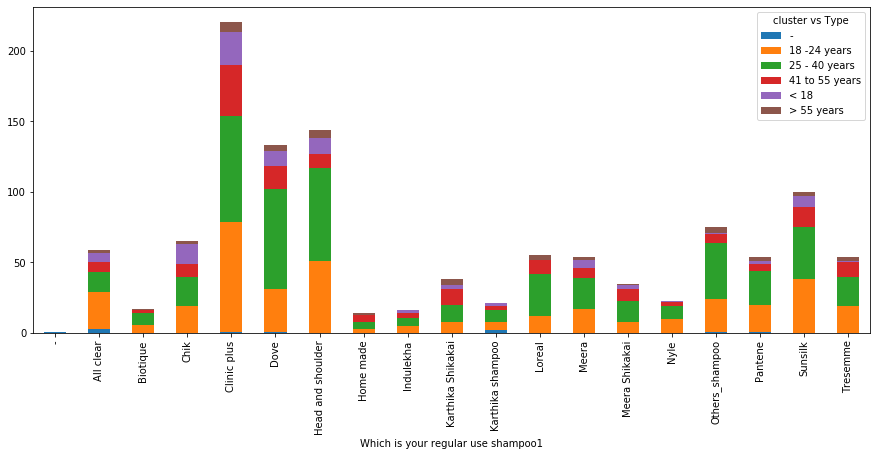

```python
ct.plot.bar(figsize = (15, 6), stacked=True)
plt.legend(title='cluster vs Type')
plt.show()
```

```python
st.chi2_contingency(ct)
```

```
(257.6895571325515,
 4.3716818623875784e-18,
 90,
 array([[8.48896435e-03, 3.20882852e-01, 4.10865874e-01, 1.40067912e-01,
         8.06451613e-02, 3.90492360e-02],
        [5.00848896e-01, 1.89320883e+01, 2.42410866e+01, 8.26400679e+00,
         4.75806452e+00, 2.30390492e+00],
        [1.44312394e-01, 5.45500849e+00, 6.98471986e+00, 2.38115450e+00,
         1.37096774e+00, 6.63837012e-01],
        [5.51782683e-01, 2.08573854e+01, 2.67062818e+01, 9.10441426e+00,
         5.24193548e+00, 2.53820034e+00],
        [1.86757216e+00, 7.05942275e+01, 9.03904924e+01, 3.08149406e+01,
         1.77419355e+01, 8.59083192e+00],
        [1.12903226e+00, 4.26774194e+01, 5.46451613e+01, 1.86290323e+01,
         1.07258065e+01, 5.19354839e+00],
        [1.22241087e+00, 4.62071307e+01, 5.91646859e+01, 2.01697793e+01,
         1.16129032e+01, 5.62308998e+00],
        [1.18845501e-01, 4.49235993e+00, 5.75212224e+00, 1.96095076e+00,
         1.12903226e+00, 5.46689304e-01],
        [1.35823430e-01, 5.13412564e+00, 6.57385399e+00, 2.24108659e+00,
         1.29032258e+00, 6.24787776e-01],
        [3.22580645e-01, 1.21935484e+01, 1.56129032e+01, 5.32258065e+00,
         3.06451613e+00, 1.48387097e+00],
        [1.78268251e-01, 6.73853990e+00, 8.62818336e+00, 2.94142615e+00,
         1.69354839e+00, 8.20033956e-01],
        [4.66893039e-01, 1.76485569e+01, 2.25976231e+01, 7.70373514e+00,
         4.43548387e+00, 2.14770798e+00],
        [4.58404075e-01, 1.73276740e+01, 2.21867572e+01, 7.56366723e+00,
         4.35483871e+00, 2.10865874e+00],
        [2.97113752e-01, 1.12308998e+01, 1.43803056e+01, 4.90237691e+00,
         2.82258065e+00, 1.36672326e+00],
        [1.95246180e-01, 7.38030560e+00, 9.44991511e+00, 3.22156197e+00,
         1.85483871e+00, 8.98132428e-01],
        [6.36672326e-01, 2.40662139e+01, 3.08149406e+01, 1.05050934e+01,
         6.04838710e+00, 2.92869270e+00],
        [4.58404075e-01, 1.73276740e+01, 2.21867572e+01, 7.56366723e+00,
         4.35483871e+00, 2.10865874e+00],
        [8.48896435e-01, 3.20882852e+01, 4.10865874e+01, 1.40067912e+01,
         8.06451613e+00, 3.90492360e+00],
        [4.58404075e-01, 1.73276740e+01, 2.21867572e+01, 7.56366723e+00,
         4.35483871e+00, 2.10865874e+00]]))
```

Interpretation of Result:

- The p-value is much lower than 0.05.
- There is strong evidence that the null hypothesis is False.
- We reject the null hypothesis and conclude that there is a statistically significant correlation between the Shampoo Brand and Age.

Question 3 - Is there any statistically significant relation between Shampoo Brand Type and friendly nature ?

- Null Hypothesis H0 = Shampoo Brand and friendly nature are independent from each other.
- Alternative Hypothesis HA = Shampoo Brand and friendly nature are not independent of each other. There is a relationship between them.
- Shampoo Brand - categorical variable
- friendly nature - categorical variable

Now, to determine if there is a statistically significant correlation between the variables, we use a chi-square test of independence of variables in a contingency table

Here, we create a contingency table, with the frequencies of all possible values

```python
# Contingency table
ct = pd.crosstab(data_1['Which is your regular use shampoo1'], data_1['Who are you still in good touch with ?'])
```

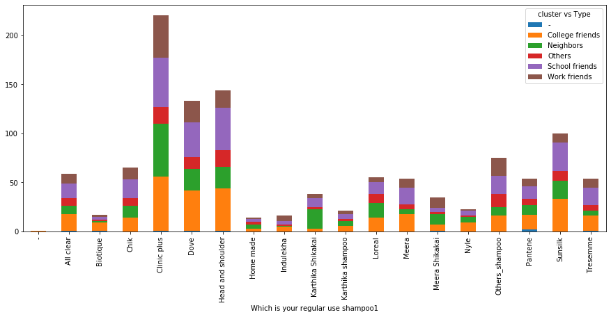

```python
ct.plot.bar(figsize = (15, 6), stacked=True)
plt.legend(title='cluster vs Type')
plt.show()
```

```python
tstat_scipy,pval_scipy,ddof_scipy,exp_scipy=chi2_contingency(ct, correction=False) # "correction=False" means no Yates' correction is used!
print("Chi-squared test statistic without Yates correction (Scipy): " + str(tstat_scipy))
print("P-value without Yates correction (Scipy): " + str(pval_scipy))
```

```
Chi-squared test statistic without Yates correction (Scipy): 122.16252793616374
P-value without Yates correction (Scipy): 0.013624267790231402
```

**Chi sqaure test for all columns**

```python
data2 = df
col = data2.columns

df_chi2 = []

ALPHA = 0.05

qc = ['-','S','S','MCQ','S','S','MCQ','S','S','MCQ','MCQ','S','S','MCQ','S','S','S','S','S','S']


for i in col:
    q1 = 'Prime channel .1'

    ct = pd.crosstab(data2[q1], data2[i])
    tstat_scipy,pval_scipy,ddof_scipy,exp_scipy=chi2_contingency(ct, correction=False) # "correction=False" means no Yates' correction is used!
    dat= [[ i, q1 ,tstat_scipy, pval_scipy]]
    dd = pd.DataFrame(dat, columns = ['attr1','attr2','tstat(chi2)', 'p'])
    df_chi2.append(dd)

df_chi = pd.concat(df_chi2, ignore_index=True)

df_chi['Question_type'] = qc
df_chi['H0'] = df_chi.p.apply(lambda x: 'rejected' if x <= ALPHA else 'fail to reject')
df_chi['relation'] = df_chi.H0.apply(lambda x: 'dependent' if x=='rejected' else 'independent')


#df_chi.style.apply(lambda x: "background: red" if x=='rejected'))
df_chi.style.applymap(lambda x: 'background-color : yellow' if H0=='rejected' else '')


def color_positive_green(val):
    """
    Takes a scalar and returns a string with
    the css property `'color: green'` for positive
    strings, black otherwise.
    """
    if val=='dependent':
        color = 'green'
    else:
        color = 'red'
    return 'color: %s' % color

df_chi.style.applymap(color_positive_green)

display(df_chi.style.applymap(color_positive_green,subset=['relation']))
```

[output not shown]

```python
df.columns
```

```
Index(['0.2)Gender', '0.3)Age', '0.4)Tag the location', '0.5)Profession',
       'Prime channel',
       '0.7)Which DTH or Cable service do you use?   DTH    ?',
       '0.8)When you want to watch TV what do you generally do ?        ?',
       'Type- spouse', 'Along with spouse', 'Along With kids',
       'What do you do when working',
       '0.12)When do you get time to relax and watch TV          &nbsp;',
       '0.13)When do your children watch TV in weekday weekend        Please note the time',
       '0.14)When do you watch TV&nbsp;along with your spouse', '0.15)',
       '0.16)Which of the above news channels gives more accurate news , according to you&nbsp;&nbsp;   ,',
       '0.17)Name some programs telecasted in this channel',
       '0.18)Please type an answer ..!      ..!',
       '0.19)Name some programs telecasted in this channel',
       '0.20)Please type an answer ..!      ..!',
       '0.21)Name of the program or Anchors name in the below channels',
       '0.22)', '0.23)What hair problems do you have ?     ?',
       '0.24)Which shampoo do you use regularly',
       '0.25)I am using shampoo for my hair problem , if not why ?       ,  ?',
       '0.26)Do you use bottle or sachet', '0.27)Cost of the sachet  Bottle',
       '0.28)Please type your phone number',
       '0.29)What is your email address?', 'Type', 'Prime channel .1', 'Type',
       'Channel 2', 'Channel 2 no.', 'Channel 3', 'Channel 3 no.',
       'Channel 31 no.', 'Channel 32 no.'],
      dtype='object')
```

```python
# Enconded table with dummy columns

df = data_1
a = df['How do you spend your morning time during Weekdays?'].str.get_dummies(sep=',').rename(columns={'Watch TV ':'WatchTV'})
b = df['Select the responses  Options that match your views?'].str.get_dummies(sep=',')
c = df['Before you go to sleep what you typically do?'].str.get_dummies(sep=',').rename(columns={'Watch TV':'Watch_TV'})
d = df['What do you look for when visiting social media reading newspaper'].str.get_dummies(sep=',').rename(columns={'-':'--'})

a0 = pd.get_dummies(df['Age']).rename(columns={'-':'---'})
a1 = pd.get_dummies(df['Gender'])
#a2 = pd.get_dummies(df['Which is the most frequently used payment mode for paying Household items  Electricity bills etc'])
#a3 = pd.get_dummies(df['Which type do you use']).rename(columns={'-':'----'})
#a4 = pd.get_dummies(df['Which is your regular use shampoo1']).rename(columns={'-':'-----'})


ds = df.join(a0).join(a1).join(a).join(b).join(c).join(d)
```

```python
ds1 = ds[ds.columns[~ds.columns.isin(['Response ID',
   'Before you go to sleep what you typically do?',
   'Brand and shade of hair color', 'Do you use hair dye  Hair color',
   'How do you spend your morning time during Weekdays?',
   'In my opinion, imported products',
   'Please list any two recently watched advertisement Mention the brand name of the Adv',
   'Select the responses  Options that match your views?',
   'What do you look for when visiting social media reading newspaper',
   'What is your opinion on home made remedies?',
   'What would you like to do in your free time',
   'When you listen to music',
   'Which is the most frequently used payment mode for paying Household items  Electricity bills etc',
   'Which is your regular use shampoo',
   'Which of the following you think influences people the most?',
   'Which type do you use', 'Who are you still in good touch with ?',
 '-','--','---','----','Please list any two recently watched advertisement (Mention the brand name of the Adv)'])]]
```

```python
ds1
```

|  | Age | Gender | Which is your regular use shampoo1 | Do you use hair dye Hair color1 | 18 -24 years | 25 - 40 years | 41 to 55 years | < 18 | > 55 years | Female | ... | Reading books | Spend time with family | Watch_TV | Economics News | Local news | Movies Actors Gossips | Read horoscope | Read recipes | Sales News | Sports News |
| --- | --- | --- | --- | --- | --- | --- | --- | --- | --- | --- | --- | --- | --- | --- | --- | --- | --- | --- | --- | --- | --- |
| 0 | 25 - 40 years | Male | Head and shoulder | No | 0 | 1 | 0 | 0 | 0 | 0 | ... | 0 | 0 | 0 | 0 | 0 | 0 | 0 | 0 | 0 | 1 |
| 1 | 18 -24 years | Female | Chik | No | 1 | 0 | 0 | 0 | 0 | 1 | ... | 0 | 0 | 1 | 0 | 1 | 0 | 0 | 0 | 0 | 0 |
| 2 | 25 - 40 years | Female | Dove | Yes | 0 | 1 | 0 | 0 | 0 | 1 | ... | 0 | 1 | 0 | 1 | 1 | 1 | 0 | 0 | 0 | 0 |
| 3 | 18 -24 years | Female | Dove | No | 1 | 0 | 0 | 0 | 0 | 1 | ... | 0 | 0 | 0 | 0 | 0 | 0 | 0 | 0 | 0 | 1 |
| 4 | 41 to 55 years | Female | Clinic plus | No | 0 | 0 | 1 | 0 | 0 | 1 | ... | 0 | 0 | 0 | 0 | 0 | 0 | 1 | 0 | 0 | 0 |
| ... | ... | ... | ... | ... | ... | ... | ... | ... | ... | ... | ... | ... | ... | ... | ... | ... | ... | ... | ... | ... | ... |
| 1173 | 18 -24 years | Female | Clinic plus | No | 1 | 0 | 0 | 0 | 0 | 1 | ... | 0 | 0 | 1 | 0 | 1 | 0 | 0 | 0 | 0 | 0 |
| 1174 | 25 - 40 years | Male | Home made | No | 0 | 1 | 0 | 0 | 0 | 0 | ... | 0 | 0 | 0 | 0 | 1 | 1 | 0 | 0 | 0 | 0 |
| 1175 | 25 - 40 years | Male | Clinic plus | No | 0 | 1 | 0 | 0 | 0 | 0 | ... | 0 | 0 | 0 | 0 | 0 | 1 | 0 | 0 | 0 | 0 |
| 1176 | 18 -24 years | Male | All clear | No | 1 | 0 | 0 | 0 | 0 | 0 | ... | 0 | 0 | 0 | 1 | 1 | 0 | 0 | 0 | 0 | 0 |
| 1177 | 25 - 40 years | Female | Dove | Yes | 0 | 1 | 0 | 0 | 0 | 1 | ... | 0 | 1 | 0 | 1 | 1 | 1 | 0 | 1 | 1 | 0 |

1178 rows × 43 columns

```python
data2 = df
col = data2.columns

df_chi2 = []

ALPHA = 0.05

#qc = ['-','S','S','MCQ','S','S','MCQ','S','S','MCQ','MCQ','S','S','MCQ','S','S','S','S','S','S']


for i in col:
    q1 = 'Prime channel .1'

    ct = pd.crosstab(data2[q1], data2[i])
    tstat_scipy,pval_scipy,ddof_scipy,exp_scipy=chi2_contingency(ct, correction=False) # "correction=False" means no Yates' correction is used!
    dat= [[ i, q1 ,tstat_scipy, pval_scipy]]
    dd = pd.DataFrame(dat, columns = ['attr1','attr2','tstat(chi2)', 'p'])
    df_chi2.append(dd)

df_chi = pd.concat(df_chi2, ignore_index=True)

#df_chi['Question_type'] = qc
df_chi['H0'] = df_chi.p.apply(lambda x: 'rejected' if x <= ALPHA else 'fail to reject')
df_chi['relation'] = df_chi.H0.apply(lambda x: 'dependent' if x=='rejected' else 'independent')


#df_chi.style.apply(lambda x: "background: red" if x=='rejected'))
df_chi.style.applymap(lambda x: 'background-color : yellow' if H0=='rejected' else '')


def color_positive_green(val):
    """
    Takes a scalar and returns a string with
    the css property `'color: green'` for positive
    strings, black otherwise.
    """
    if val=='dependent':
        color = 'green'
    else:
        color = 'red'
    return 'color: %s' % color

df_chi.style.applymap(color_positive_green)

display(df_chi.style.applymap(color_positive_green,subset=['relation']))
```

[output not shown]

### Cramers V

```python
#For statistical tests
import scipy.stats as st

def cramers_v(x, y):
    confusion_matrix = pd.crosstab(x,y)
    chi2 = st.chi2_contingency(confusion_matrix)[0]
    n = confusion_matrix.sum().sum()
    phi2 = chi2/n
    r,k = confusion_matrix.shape
    phi2corr = max(0, phi2-((k-1)*(r-1))/(n-1))
    rcorr = r-((r-1)**2)/(n-1)
    kcorr = k-((k-1)**2)/(n-1)
    return np.sqrt(phi2corr/min((kcorr-1),(rcorr-1)))
```

```python
x = data_1['Which is your regular use shampoo1']

y = data_1['Which is the most frequently used payment mode for paying Household items  Electricity bills etc']


display(cramers_v(x,y))
display(cramers_v(y,x))
```

```
0.09776365864719015
```

```
0.09776365864719018
```

```python
interesting_cols = df.columns
```

```python
interesting_cols1 = ['Age', 'Gender',
       'Before you go to sleep what you typically do?',
       'Brand and shade of hair color', 'Do you use hair dye  Hair color',
       'How do you spend your morning time during Weekdays?',
       'In my opinion, imported products',
       'Select the responses  Options that match your views?',
       'What do you look for when visiting social media reading newspaper',
       'What is your opinion on home made remedies?',
       'What would you like to do in your free time',
       'When you listen to music',
       'Which is the most frequently used payment mode for paying Household items  Electricity bills etc',
       'Which of the following you think influences people the most?',
       'Which type do you use', 'Who are you still in good touch with ?',
       'Which is your regular use shampoo1']

hmi = pd.DataFrame(index=interesting_cols, columns=interesting_cols, dtype=float)
for i,j in enumerate(interesting_cols):
    for x,y in enumerate(interesting_cols):
        hmi.iloc[i,x] = cramers_v(df.loc[:,j], df.loc[:,y])


fig, ax = plt.subplots(nrows=1, ncols=1, figsize=(18, 15))
# sns.heatmap(hmi, cmap='Blues', ax=ax)
ax = sns.heatmap(hmi, linecolor='k', annot=True, linewidths=0.01, ax=ax, cbar_kws={'label': 'How much we think we know'})
t = ax.set_ylabel("How much can we infer about:")
t = ax.set_xlabel("Given that we know:")
cbar = ax.collections[0].colorbar
cbar.set_ticks([0, .5, 1])
cbar.set_ticklabels(['Not very much', 'A bit', 'Quite a lot'])
plt.tight_layout()
```

[output not shown]

```python
df = data_1
a = df['How do you spend your morning time during Weekdays?'].str.get_dummies(sep=',').rename(columns={'Watch TV ':'WatchTV'})
b = df['Select the responses  Options that match your views?'].str.get_dummies(sep=',')
c = df['Before you go to sleep what you typically do?'].str.get_dummies(sep=',').rename(columns={'Watch TV':'Watch_TV'})
d = df['What do you look for when visiting social media reading newspaper'].str.get_dummies(sep=',').rename(columns={'-':'--'})

a0 = pd.get_dummies(df['Age']).rename(columns={'-':'---'})
a1 = pd.get_dummies(df['Gender'])
a2 = pd.get_dummies(df['Which is the most frequently used payment mode for paying Household items  Electricity bills etc'])
a3 = pd.get_dummies(df['Which type do you use']).rename(columns={'-':'----'})

a4 = pd.get_dummies(df['Which is your regular use shampoo1']).rename(columns={'-':'-----'})


ds = df.join(a0).join(a1).join(a2).join(a3).join(a4).join(a).join(b).join(c).join(d)
```

```python
ds1 = ds[ds.columns[~ds.columns.isin(['Response ID', 'Age', 'Gender',
   'Before you go to sleep what you typically do?',
   'Brand and shade of hair color', 'Do you use hair dye  Hair color',
   'How do you spend your morning time during Weekdays?',
   'In my opinion, imported products',
   'Please list any two recently watched advertisement Mention the brand name of the Adv',
   'Select the responses  Options that match your views?',
   'What do you look for when visiting social media reading newspaper',
   'What is your opinion on home made remedies?',
   'What would you like to do in your free time',
   'When you listen to music',
   'Which is the most frequently used payment mode for paying Household items  Electricity bills etc',
   'Which is your regular use shampoo',
   'Which of the following you think influences people the most?',
   'Which type do you use', 'Who are you still in good touch with ?',
   'Which is your regular use shampoo1', '-','--','---','----','-----','Please list any two recently watched advertisement (Mention the brand name of the Adv)'])]]
```

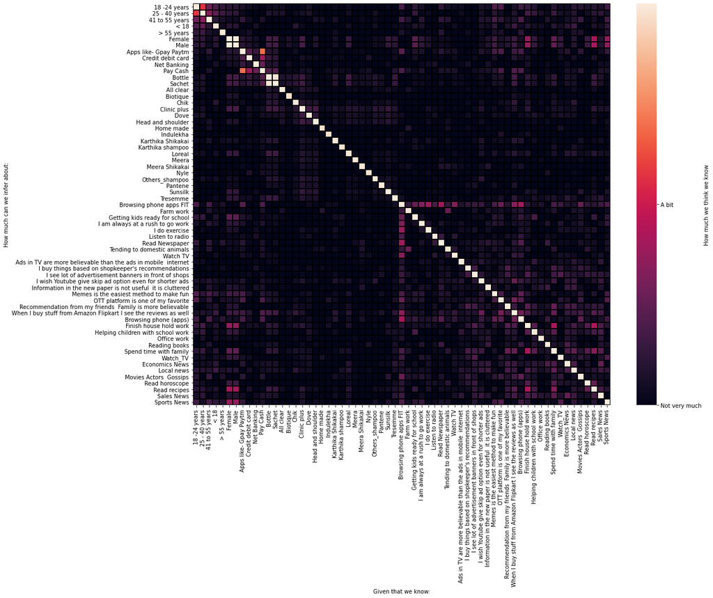

```python
interesting_cols = ['18 -24 years', '25 - 40 years', '41 to 55 years', '< 18', '> 55 years',
       'Female', 'Male', 'Apps like- Gpay Paytm', 'Credit debit card',
       'Net Banking', 'Pay Cash', 'Bottle', 'Sachet', 'All clear', 'Biotique',
       'Chik', 'Clinic plus', 'Dove', 'Head and shoulder', 'Home made',
       'Indulekha', 'Karthika Shikakai', 'Karthika shampoo', 'Loreal', 'Meera',
       'Meera Shikakai', 'Nyle', 'Others_shampoo', 'Pantene', 'Sunsilk',
       'Tresemme', 'Browsing phone apps FIT', 'Farm work',
       'Getting kids ready for school', 'I am always at a rush to go work',
       'I do exercise', 'Listen to radio', 'Read Newspaper',
       'Tending to domestic animals', 'Watch TV',
       'Ads in TV are more believable than the ads in mobile  internet',
       'I buy things based on shopkeeper\'s recommendations',
       'I see lot of advertisement banners in front of shops',
       'I wish Youtube give skip ad option even for shorter ads',
       'Information in the new paper is not useful  it is cluttered',
       'Memes is the easiest method to make fun',
       'OTT platform is one of my favorite',
       'Recommendation from my friends  Family is more believable',
       'When I buy stuff from Amazon Flipkart I see the reviews as well',
       'Browsing phone (apps)', 'Finish house hold work',
       'Helping children with school work', 'Office work', 'Reading books',
       'Spend time with family', 'Watch_TV', 'Economics News', 'Local news',
       'Movies Actors  Gossips', 'Read horoscope', 'Read recipes',
       'Sales News', 'Sports News']

hmi = pd.DataFrame(index=interesting_cols, columns=interesting_cols, dtype=float)
for i,j in enumerate(interesting_cols):
    for x,y in enumerate(interesting_cols):
        hmi.iloc[i,x] = cramers_v(ds1.loc[:,j], ds1.loc[:,y])

fig, ax = plt.subplots(nrows=1, ncols=1, figsize=(18, 15))
# sns.heatmap(hmi, cmap='Blues', ax=ax)
ax = sns.heatmap(hmi, linecolor='k', annot=False, linewidths=0.01, ax=ax, cbar_kws={'label': 'How much we think we know'})
t = ax.set_ylabel("How much can we infer about:")
t = ax.set_xlabel("Given that we know:")
cbar = ax.collections[0].colorbar
cbar.set_ticks([0, .5, 1])
cbar.set_ticklabels(['Not very much', 'A bit', 'Quite a lot'])
plt.tight_layout()
```

### Thiels

```python
import math
from collections import Counter
import sys
from scipy.stats import entropy


def handle_na(x):
    """
    Remove NaN in the data.
    :param x: a pandas column
    :return: the column without NaNs
    """
    # return x.dropna()
    return x.fillna("")


def conditional_entropy(x, y, log_base: float = math.e):
    """
    Calculates the conditional entropy of x given y: S(x|y)
    Wikipedia: https://en.wikipedia.org/wiki/Conditional_entropy
    Please see [The Dython Library](https://github.com/shakedzy/dython)
    for attribution and source
    Parameters:
    -----------
    x : list / NumPy ndarray / Pandas Series
        A sequence of measurements
    y : list / NumPy ndarray / Pandas Series
        A sequence of measurements
    log_base: float, default = e
        specifying base for calculating entropy. Default is base e.
    Returns:
    --------
    float
    """

    # remove NaN
    x = handle_na(x)
    y = handle_na(y)

    # x and y should be the same shape
    if x.shape != y.shape:
        sys.stderr.write("ERROR: In conditional entropy the two dfs must have the same shape. Not {x.shape} and {y.shape}\n")
        return 0

    y_counter = Counter(y)
    xy_counter = Counter(list(zip(x, y)))
    total_occurrences = sum(y_counter.values())
    entrop = 0.0
    for xy in xy_counter.keys():
        p_xy = xy_counter[xy] / total_occurrences
        p_y = y_counter[xy[1]] / total_occurrences
        entrop += -1 * p_xy * math.log(p_xy / p_y, log_base)
    return entrop


def theils_u(x, y):
    """
    Calculates Theil's U statistic (Uncertainty coefficient) for categorical-
    categorical association. This is the uncertainty of x given y: value is
    on the range of [0,1] - where 0 means y provides no information about
    x, and 1 means y provides full information about x.
    This is an asymmetric coefficient: U(x,y) != U(y,x)
    Please see [The Dython Library](https://github.com/shakedzy/dython)
    for attribution and source
    Wikipedia: https://en.wikipedia.org/wiki/Uncertainty_coefficient
    Parameters:
    -----------
    x : list / NumPy ndarray / Pandas Series
        A sequence of categorical measurements
    y : list / NumPy ndarray / Pandas Series
        A sequence of categorical measurements
    Returns:
    --------
    float in the range of [0,1]
    """

    # remove NaN
    x = handle_na(x)
    y = handle_na(y)

    s_xy = conditional_entropy(x, y)
    x_counter = Counter(x)
    total_occurrences = sum(x_counter.values())
    p_x = list(map(lambda n: n / total_occurrences, x_counter.values()))
    s_x = entropy(p_x)
    if s_x == 0:
        return 1
    else:
        return (s_x - s_xy) / s_x
```

```python
x = data_1['Which is your regular use shampoo1']

y = data_1['Which is the most frequently used payment mode for paying Household items  Electricity bills etc']


display(theils_u(x,y))
display(theils_u(y,x))
```

```
0.015065695246758992
```

```
0.03635831755119185
```

```python
interesting_cols1 = ['Age', 'Gender',
       'Before you go to sleep what you typically do?',
       'Brand and shade of hair color', 'Do you use hair dye  Hair color',
       'How do you spend your morning time during Weekdays?',
       'In my opinion, imported products',
       'Select the responses  Options that match your views?',
       'What do you look for when visiting social media reading newspaper',
       'What is your opinion on home made remedies?',
       'What would you like to do in your free time',
       'When you listen to music',
       'Which is the most frequently used payment mode for paying Household items  Electricity bills etc',
       'Which of the following you think influences people the most?',
       'Which type do you use', 'Who are you still in good touch with ?',
       'Which is your regular use shampoo1']

hmi = pd.DataFrame(index=interesting_cols, columns=interesting_cols, dtype=float)
for i,j in enumerate(interesting_cols):
    for x,y in enumerate(interesting_cols):
        hmi.iloc[i,x] = theils_u(df.loc[:,j], df.loc[:,y])
```

[figure not shown]

```python
fig, ax = plt.subplots(nrows=1, ncols=1, figsize=(18, 15))
# sns.heatmap(hmi, cmap='Blues', ax=ax)
ax = sns.heatmap(hmi, linecolor='k', annot=True, linewidths=0.01, ax=ax, cbar_kws={'label': 'How much we think we know'})
t = ax.set_ylabel("How much can we infer about:")
t = ax.set_xlabel("Given that we know:")
cbar = ax.collections[0].colorbar
cbar.set_ticks([0, .5, 1])
cbar.set_ticklabels(['Not very much', 'A bit', 'Quite a lot'])
plt.tight_layout()
```

```python
ds1 = ds[ds.columns[~ds.columns.isin(['Response ID', 'Age', 'Gender',
   'Before you go to sleep what you typically do?',
   'Brand and shade of hair color', 'Do you use hair dye  Hair color',
   'How do you spend your morning time during Weekdays?',
   'In my opinion, imported products',
   'Please list any two recently watched advertisement Mention the brand name of the Adv',
   'Select the responses  Options that match your views?',
   'What do you look for when visiting social media reading newspaper',
   'What is your opinion on home made remedies?',
   'What would you like to do in your free time',
   'When you listen to music',
   'Which is the most frequently used payment mode for paying Household items  Electricity bills etc',
   'Which is your regular use shampoo',
   'Which of the following you think influences people the most?',
   'Which type do you use', 'Who are you still in good touch with ?',
   'Which is your regular use shampoo1', '-','--','---','----','-----','Please list any two recently watched advertisement (Mention the brand name of the Adv)'])]]
```

```python
ds1
```

|  | 18 -24 years | 25 - 40 years | 41 to 55 years | < 18 | > 55 years | Female | Male | Apps like- Gpay Paytm | Credit debit card | Net Banking | ... | Reading books | Spend time with family | Watch_TV | Economics News | Local news | Movies Actors Gossips | Read horoscope | Read recipes | Sales News | Sports News |
| --- | --- | --- | --- | --- | --- | --- | --- | --- | --- | --- | --- | --- | --- | --- | --- | --- | --- | --- | --- | --- | --- |
| 0 | 0 | 1 | 0 | 0 | 0 | 0 | 1 | 0 | 0 | 0 | ... | 0 | 0 | 0 | 0 | 0 | 0 | 0 | 0 | 0 | 1 |
| 1 | 1 | 0 | 0 | 0 | 0 | 1 | 0 | 0 | 0 | 0 | ... | 0 | 0 | 1 | 0 | 1 | 0 | 0 | 0 | 0 | 0 |
| 2 | 0 | 1 | 0 | 0 | 0 | 1 | 0 | 0 | 0 | 0 | ... | 0 | 1 | 0 | 1 | 1 | 1 | 0 | 0 | 0 | 0 |
| 3 | 1 | 0 | 0 | 0 | 0 | 1 | 0 | 0 | 0 | 0 | ... | 0 | 0 | 0 | 0 | 0 | 0 | 0 | 0 | 0 | 1 |
| 4 | 0 | 0 | 1 | 0 | 0 | 1 | 0 | 0 | 0 | 0 | ... | 0 | 0 | 0 | 0 | 0 | 0 | 1 | 0 | 0 | 0 |
| ... | ... | ... | ... | ... | ... | ... | ... | ... | ... | ... | ... | ... | ... | ... | ... | ... | ... | ... | ... | ... | ... |
| 1173 | 1 | 0 | 0 | 0 | 0 | 1 | 0 | 0 | 0 | 0 | ... | 0 | 0 | 1 | 0 | 1 | 0 | 0 | 0 | 0 | 0 |
| 1174 | 0 | 1 | 0 | 0 | 0 | 0 | 1 | 1 | 0 | 0 | ... | 0 | 0 | 0 | 0 | 1 | 1 | 0 | 0 | 0 | 0 |
| 1175 | 0 | 1 | 0 | 0 | 0 | 0 | 1 | 0 | 0 | 0 | ... | 0 | 0 | 0 | 0 | 0 | 1 | 0 | 0 | 0 | 0 |
| 1176 | 1 | 0 | 0 | 0 | 0 | 0 | 1 | 0 | 0 | 0 | ... | 0 | 0 | 0 | 1 | 1 | 0 | 0 | 0 | 0 | 0 |
| 1177 | 0 | 1 | 0 | 0 | 0 | 1 | 0 | 1 | 0 | 0 | ... | 0 | 1 | 0 | 1 | 1 | 1 | 0 | 1 | 1 | 0 |

1178 rows × 63 columns

```python
ds1.columns
```

```
Index(['18 -24 years', '25 - 40 years', '41 to 55 years', '< 18', '> 55 years',
       'Female', 'Male', 'Apps like- Gpay Paytm', 'Credit debit card',
       'Net Banking', 'Pay Cash', 'Bottle', 'Sachet', 'All clear', 'Biotique',
       'Chik', 'Clinic plus', 'Dove', 'Head and shoulder', 'Home made',
       'Indulekha', 'Karthika Shikakai', 'Karthika shampoo', 'Loreal', 'Meera',
       'Meera Shikakai', 'Nyle', 'Others_shampoo', 'Pantene', 'Sunsilk',
       'Tresemme', 'Browsing phone apps FIT', 'Farm work',
       'Getting kids ready for school', 'I am always at a rush to go work',
       'I do exercise', 'Listen to radio', 'Read Newspaper',
       'Tending to domestic animals', 'Watch TV',
       'Ads in TV are more believable than the ads in mobile  internet',
       'I buy things based on shopkeeper's recommendations',
       'I see lot of advertisement banners in front of shops',
       'I wish Youtube give skip ad option even for shorter ads',
       'Information in the new paper is not useful  it is cluttered',
       'Memes is the easiest method to make fun',
       'OTT platform is one of my favorite',
       'Recommendation from my friends  Family is more believable',
       'When I buy stuff from Amazon Flipkart I see the reviews as well',
       'Browsing phone (apps)', 'Finish house hold work',
       'Helping children with school work', 'Office work', 'Reading books',
       'Spend time with family', 'Watch_TV', 'Economics News', 'Local news',
       'Movies Actors  Gossips', 'Read horoscope', 'Read recipes',
       'Sales News', 'Sports News'],
      dtype='object')
```

```python
interesting_cols = ['18 -24 years', '25 - 40 years', '41 to 55 years', '< 18', '> 55 years',
       'Female', 'Male', 'Apps like- Gpay Paytm', 'Credit debit card',
       'Net Banking', 'Pay Cash', 'Bottle', 'Sachet', 'All clear', 'Biotique',
       'Chik', 'Clinic plus', 'Dove', 'Head and shoulder', 'Home made',
       'Indulekha', 'Karthika Shikakai', 'Karthika shampoo', 'Loreal', 'Meera',
       'Meera Shikakai', 'Nyle', 'Others_shampoo', 'Pantene', 'Sunsilk',
       'Tresemme', 'Browsing phone apps FIT', 'Farm work',
       'Getting kids ready for school', 'I am always at a rush to go work',
       'I do exercise', 'Listen to radio', 'Read Newspaper',
       'Tending to domestic animals', 'Watch TV',
       'Ads in TV are more believable than the ads in mobile  internet',
       'I buy things based on shopkeeper\'s recommendations',
       'I see lot of advertisement banners in front of shops',
       'I wish Youtube give skip ad option even for shorter ads',
       'Information in the new paper is not useful  it is cluttered',
       'Memes is the easiest method to make fun',
       'OTT platform is one of my favorite',
       'Recommendation from my friends  Family is more believable',
       'When I buy stuff from Amazon Flipkart I see the reviews as well',
       'Browsing phone (apps)', 'Finish house hold work',
       'Helping children with school work', 'Office work', 'Reading books',
       'Spend time with family', 'Watch_TV', 'Economics News', 'Local news',
       'Movies Actors  Gossips', 'Read horoscope', 'Read recipes',
       'Sales News', 'Sports News']

hmi = pd.DataFrame(index=interesting_cols, columns=interesting_cols, dtype=float)
for i,j in enumerate(interesting_cols):
    for x,y in enumerate(interesting_cols):
        hmi.iloc[i,x] = theils_u(ds1.loc[:,j], ds1.loc[:,y])
```

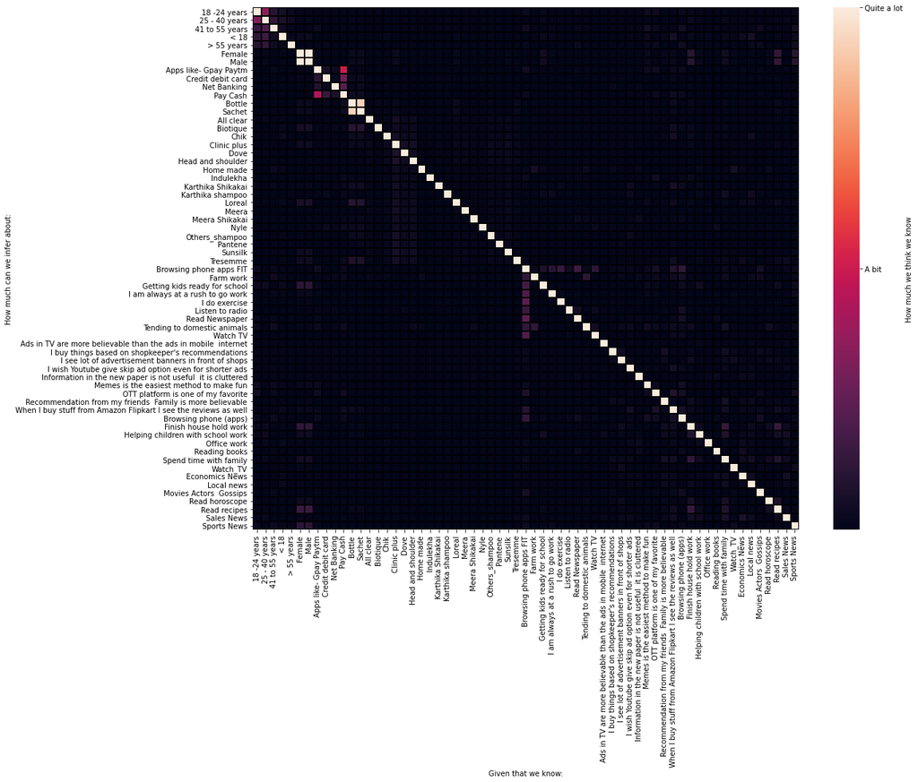

```python
fig, ax = plt.subplots(nrows=1, ncols=1, figsize=(18, 15))
# sns.heatmap(hmi, cmap='Blues', ax=ax)
ax = sns.heatmap(hmi, linecolor='k', annot=False, linewidths=0.01, ax=ax, cbar_kws={'label': 'How much we think we know'})
t = ax.set_ylabel("How much can we infer about:")
t = ax.set_xlabel("Given that we know:")
cbar = ax.collections[0].colorbar
cbar.set_ticks([0, .5, 1])
cbar.set_ticklabels(['Not very much', 'A bit', 'Quite a lot'])
plt.tight_layout()
```

```python
df = data_1
b = df['Select the responses  Options that match your views?'].str.get_dummies(sep=',')
c = df['Before you go to sleep what you typically do?'].str.get_dummies(sep=',').rename(columns={'Watch TV':'Watch_TV'})

ds = df.join(b).join(c)
```

```python
ds1 = ds[ds.columns[~ds.columns.isin(['Response ID', 'Age', 'Gender',
   'Before you go to sleep what you typically do?',
   'Brand and shade of hair color', 'Do you use hair dye  Hair color',
   'How do you spend your morning time during Weekdays?',
   'In my opinion, imported products',
   'Please list any two recently watched advertisement Mention the brand name of the Adv',
   'Select the responses  Options that match your views?',
   'What do you look for when visiting social media reading newspaper',
   'What is your opinion on home made remedies?',
   'What would you like to do in your free time',
   'When you listen to music',
   'Which is the most frequently used payment mode for paying Household items  Electricity bills etc',
   'Which is your regular use shampoo',
   'Which of the following you think influences people the most?',
   'Which type do you use', 'Who are you still in good touch with ?',
   'Which is your regular use shampoo1', '-','--','---','----','-----','Please list any two recently watched advertisement (Mention the brand name of the Adv)'])]]
```

```python
interesting_cols = ['Ads in TV are more believable than the ads in mobile  internet',
       'I buy things based on shopkeeper\'s recommendations',
       'I see lot of advertisement banners in front of shops',
       'I wish Youtube give skip ad option even for shorter ads',
       'Information in the new paper is not useful  it is cluttered',
       'Memes is the easiest method to make fun',
       'OTT platform is one of my favorite',
       'Recommendation from my friends  Family is more believable',
       'When I buy stuff from Amazon Flipkart I see the reviews as well',
       'Browsing phone (apps)', 'Finish house hold work',
       'Helping children with school work', 'Office work', 'Reading books',
       'Spend time with family', 'Watch_TV']

hmi = pd.DataFrame(index=interesting_cols, columns=interesting_cols, dtype=float)
for i,j in enumerate(interesting_cols):
    for x,y in enumerate(interesting_cols):
        hmi.iloc[i,x] = theils_u(ds1.loc[:,j], ds1.loc[:,y])
```

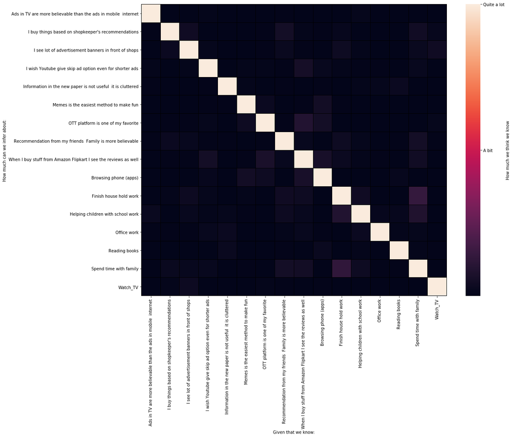

```python
fig, ax = plt.subplots(nrows=1, ncols=1, figsize=(18, 15))
# sns.heatmap(hmi, cmap='Blues', ax=ax)
ax = sns.heatmap(hmi, linecolor='k', annot=False, linewidths=0.01, ax=ax, cbar_kws={'label': 'How much we think we know'})
t = ax.set_ylabel("How much can we infer about:")
t = ax.set_xlabel("Given that we know:")
cbar = ax.collections[0].colorbar
cbar.set_ticks([0, .5, 1])
cbar.set_ticklabels(['Not very much', 'A bit', 'Quite a lot'])
plt.tight_layout()
```

### Correspondence Analysis

```python
# Crosstabulation of two categorical columns
pd.crosstab(data_1['Gender'], data_1['Age'], dropna=True)
```

| Age Gender | - | 18 -24 years | 25 - 40 years | 41 to 55 years | < 18 | > 55 years |
| --- | --- | --- | --- | --- | --- | --- |
| Female | 5 | 165 | 289 | 96 | 31 | 27 |
| Male | 5 | 213 | 195 | 69 | 64 | 19 |

```python
df.columns
```

```
Index(['0.2)Gender', '0.3)Age', '0.4)Tag the location', '0.5)Profession',
       'Prime channel',
       '0.7)Which DTH or Cable service do you use?   DTH    ?',
       '0.8)When you want to watch TV what do you generally do ?        ?',
       'Type- spouse', 'Along with spouse', 'Along With kids',
       'What do you do when working',
       '0.12)When do you get time to relax and watch TV          &nbsp;',
       '0.13)When do your children watch TV in weekday weekend        Please note the time',
       '0.14)When do you watch TV&nbsp;along with your spouse', '0.15)',
       '0.16)Which of the above news channels gives more accurate news , according to you&nbsp;&nbsp;   ,',
       '0.17)Name some programs telecasted in this channel',
       '0.18)Please type an answer ..!      ..!',
       '0.19)Name some programs telecasted in this channel',
       '0.20)Please type an answer ..!      ..!',
       '0.21)Name of the program or Anchors name in the below channels',
       '0.22)', '0.23)What hair problems do you have ?     ?',
       '0.24)Which shampoo do you use regularly',
       '0.25)I am using shampoo for my hair problem , if not why ?       ,  ?',
       '0.26)Do you use bottle or sachet', '0.27)Cost of the sachet  Bottle',
       '0.28)Please type your phone number',
       '0.29)What is your email address?', 'Type', 'Prime channel .1', 'Type',
       'Channel 2', 'Channel 2 no.', 'Channel 3', 'Channel 3 no.',
       'Channel 31 no.', 'Channel 32 no.'],
      dtype='object')
```

```python
# Crosstabulation of two categorical columns
dfch = pd.crosstab(df['Prime channel .1'], df['Channel 2'], dropna=True)
```

```python
dfch[~(dfch == 0).any(axis=1)]
```

| Channel 2 | Gemini music | Sony TV | Star gold | Star maa | bhakti TV | e TV | internet | ntv | star maa | youtube | ... | internet | maa movies | maa tv | star movies | star plus | star sports | tv9 | zee Tv | zee cinema | zee telugu |
| --- | --- | --- | --- | --- | --- | --- | --- | --- | --- | --- | --- | --- | --- | --- | --- | --- | --- | --- | --- | --- | --- |
| Prime channel .1 |  |  |  |  |  |  |  |  |  |  |  |  |  |  |  |  |  |  |  |  |  |

0 rows × 29 columns

```python
dfch

dfch = dfch.loc[:, (dfch != 0).any(axis=0)] # remove columns with all zeros
dfch.loc[~(dfch==0).all(axis=1)]  # remove rows with all zeros
```

[output not shown]

22 rows × 29 columns

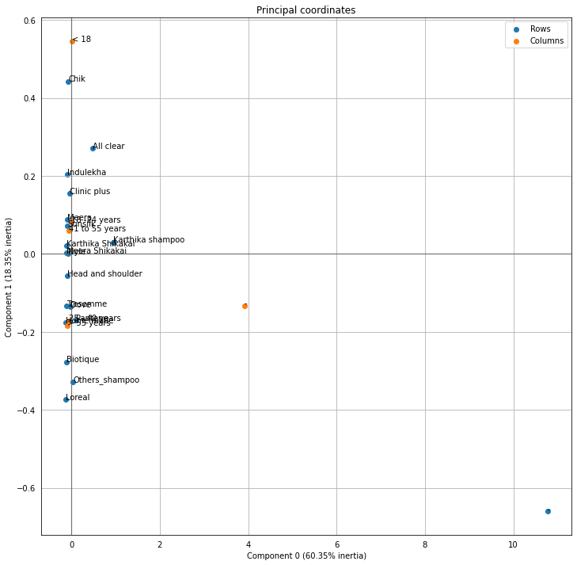

```python
df = pd.crosstab(data_1['Which is your regular use shampoo1'], data_1['Age'])
idx = df.columns.union(df.index)
df = df.reindex(index = idx, columns=idx, fill_value=0)

df = df.loc[:, (df != 0).any(axis=0)] # remove columns with all zeros
df = df.loc[~(df==0).all(axis=1)]  # remove rows with all zeros


ca = prince.CA()
ca.fit(df)

try:
    ca.plot_coordinates(df
                    ,figsize=(12, 12)
                    ,x_component=0
                    ,y_component=1
                    ,show_row_labels=True
                    ,show_col_labels=True
                    )
except ZeroDivisionError:
    z = 0
```

```python
def correspondence_analysis(data_1,column1,column2):
    df = pd.crosstab(data_1[column1], data_1[column2])
    idx = df.columns.union(df.index)
    df = df.reindex(index = idx, columns=idx, fill_value=0)

    df = df.loc[:, (df != 0).any(axis=0)] # remove columns with all zeros
    df = df.loc[~(df==0).all(axis=1)]  # remove rows with all zeros

    ca = prince.CA()
    ca.fit(df)


    try:
        ca.plot_coordinates(df
                        ,figsize=(30, 30)
                        ,x_component=1
                        ,y_component=0
                        ,show_row_labels=True
                        ,show_col_labels=True
                        )
    except ZeroDivisionError:
        z = 0
    #print(ca.row_coordinates(df),ca.column_coordinates(df))
    print("Eigen values: ", ca.eigenvalues_)
    print("Total inertia: ", ca.total_inertia_)
    print("Explained inertia: ", ca.explained_inertia_)

    explained_inertia = round(ca.explained_inertia_[0]*100) + round(ca.explained_inertia_[1]*100)

    print("It seems Component1 explained around ",round(ca.explained_inertia_[0]*100),"% and Component2 explained about ",round(ca.explained_inertia_[1]*100),"%, so two-dimension feature explained about",explained_inertia, "% of the original dimension.")
```

```python
df.columns
```

```
Index(['0.2)Gender', '0.3)Age', '0.4)Tag the location', '0.5)Profession',
       'Prime channel',
       '0.7)Which DTH or Cable service do you use?   DTH    ?',
       '0.8)When you want to watch TV what do you generally do ?        ?',
       'Type- spouse', 'Along with spouse', 'Along With kids',
       'What do you do when working',
       '0.12)When do you get time to relax and watch TV          &nbsp;',
       '0.13)When do your children watch TV in weekday weekend        Please note the time',
       '0.14)When do you watch TV&nbsp;along with your spouse', '0.15)',
       '0.16)Which of the above news channels gives more accurate news , according to you&nbsp;&nbsp;   ,',
       '0.17)Name some programs telecasted in this channel',
       '0.18)Please type an answer ..!      ..!', '0.181',
       '0.19)Name some programs telecasted in this channel',
       '0.20)Please type an answer ..!      ..!', '0.201',
       '0.21)Name of the program or Anchors name in the below channels',
       '0.22)', '0.221', '0.23)What hair problems do you have ?     ?',
       '0.24)Which shampoo do you use regularly',
       '0.25)I am using shampoo for my hair problem , if not why ?       ,  ?',
       '0.26)Do you use bottle or sachet', '0.27)Cost of the sachet  Bottle',
       '0.28)Please type your phone number',
       '0.29)What is your email address?', 'Type', 'Prime channel .1', 'Type',
       'Channel 2', 'Channel 2 no.', 'Channel 3', 'Channel 3 no.',
       'Channel 31 no.', 'Channel 32 no.'],
      dtype='object')
```

```python
#Prime channel Vs spouse watching channel
#Prime channel Vs Children watching channel
#Age Vs Prime channel
#Gender vs Prime channel
#Profession Vs prime channel
#Type of connection to type of program
Age Vs Low cost channels - 3 questions
Gender vs Low cost channels - 3 questions
```

[output not shown]

[figure not shown]

```python
#correspondence_analysis(df,'Prime channel .1','0.2)Gender')

#correspondence_analysis(df,'Prime channel .1','0.3)Age')

#correspondence_analysis(df,'Prime channel .1','0.5)Profession')

#correspondence_analysis(df,'0.7)Which DTH or Cable service do you use?   DTH    ?','Type')
```

[output not shown]

[figure not shown]

```python
#correspondence_analysis(df,'Prime channel .1','Along with spouse')

#correspondence_analysis(df,'Prime channel .1','Along With kids')

#correspondence_analysis(df,'Along with spouse','Along With kids')
```

```
Eigen values:  [0.024230885937244952, 0.01491269648543222]
Total inertia:  0.04374154786069316
Explained inertia:  [0.553955841124205, 0.3409274983346669]
It seems Component1 explained around  55 % and Component2 explained about  34 %, so two-dimension feature explained about 89 % of the original dimension.
```

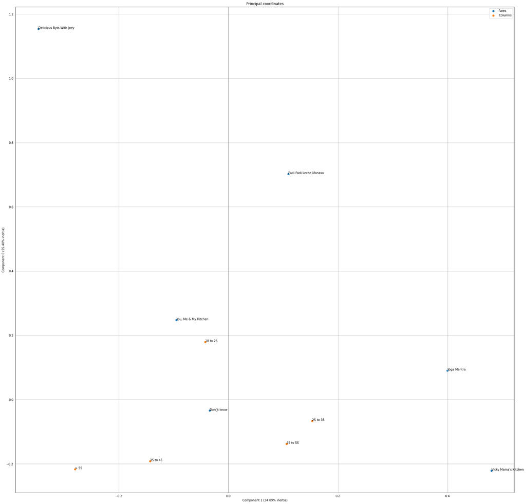

```python
#correspondence_analysis(df,'0.181','0.2)Gender')
correspondence_analysis(df,'0.181','0.3)Age')

#correspondence_analysis(df,'0.201','0.2)Gender')
#correspondence_analysis(df,'0.201','0.3)Age')

#correspondence_analysis(df,'0.22)','0.2)Gender')
#correspondence_analysis(df,'0.22)','0.3)Age')
```

```python
name = 'adf-batch-output/CSNG_Customer_Master.csv'
```

```python
name.split('/')[1]
```

```
'CSNG_Customer_Master.csv'
```

[output not shown]

[figure not shown]

```python
# Crosstabulation of two categorical columns

#correspondence_analysis(df,'0.181','0.12)When do you get time to relax and watch TV          &nbsp;')
#correspondence_analysis(df,'0.181','0.13)When do your children watch TV in weekday weekend        Please note the time')
#correspondence_analysis(df,'0.181','0.14)When do you watch TV&nbsp;along with your spouse')

#correspondence_analysis(df,'0.201','0.12)When do you get time to relax and watch TV          &nbsp;')
#correspondence_analysis(df,'0.201','0.13)When do your children watch TV in weekday weekend        Please note the time')
#correspondence_analysis(df,'0.201','0.14)When do you watch TV&nbsp;along with your spouse')

#correspondence_analysis(df,'0.22)','0.12)When do you get time to relax and watch TV          &nbsp;')
#correspondence_analysis(df,'0.22)','0.13)When do your children watch TV in weekday weekend        Please note the time')
#correspondence_analysis(df,'0.22)','0.14)When do you watch TV&nbsp;along with your spouse')

#correspondence_analysis(df,'Prime channel .1','0.181')
#correspondence_analysis(df,'Prime channel .1','0.201')
#correspondence_analysis(df,'Prime channel .1','0.22)')
```

```
Eigen values:  [0.062303687553843454, 0.03455425504039575]
Total inertia:  0.10928578267973832
Explained inertia:  [0.570098745016305, 0.31618252798405533]
It seems Component1 explained around  57 % and Component2 explained about  32 %, so two-dimension feature explained about 89 % of the original dimension.
```

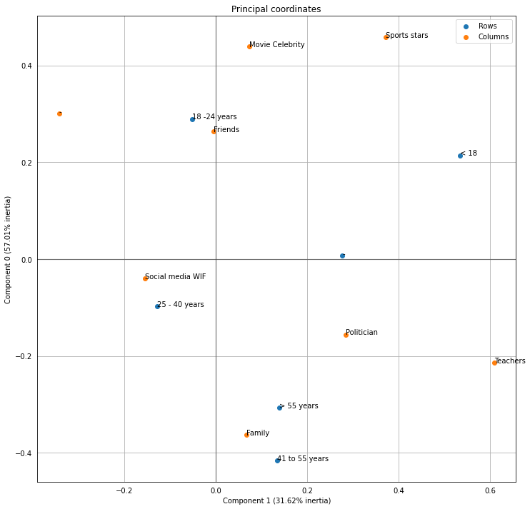

```python
# Crosstabulation of two categorical columns

correspondence_analysis('Age','Which of the following you think influences people the most?')
```

```
Eigen values:  [0.13201207131019765, 0.040139448103244366]
Total inertia:  0.2187517462924885
Explained inertia:  [0.6034789369575455, 0.18349315506526165]
It seems Component1 explained around  60 % and Component2 explained about  18 %, so two-dimension feature explained about 78 % of the original dimension.
```

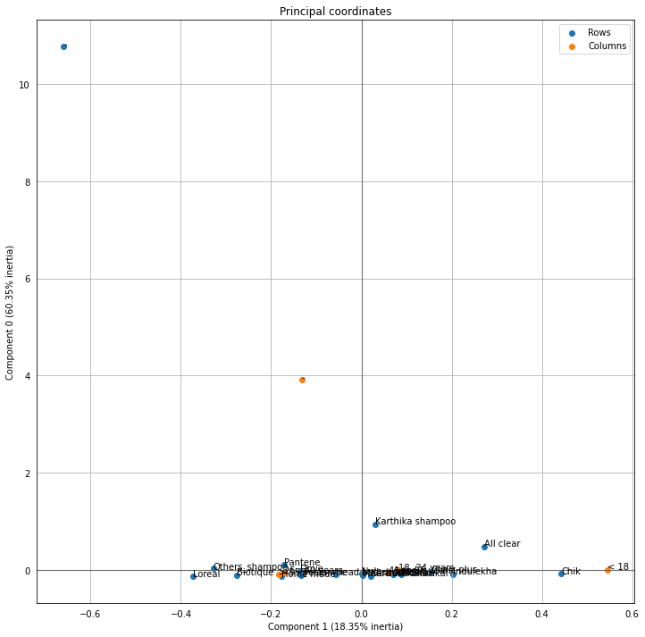

```python
correspondence_analysis('Which is your regular use shampoo1','Age')
```

```
Eigen values:  [0.11428801895706422, 4.685619366052638e-32]
Total inertia:  0.11428801895706418
Explained inertia:  [1.0000000000000004, 4.0998342685535e-31]
It seems Component1 explained around  100 % and Component2 explained about  0 %, so two-dimension feature explained about 100 % of the original dimension.
```

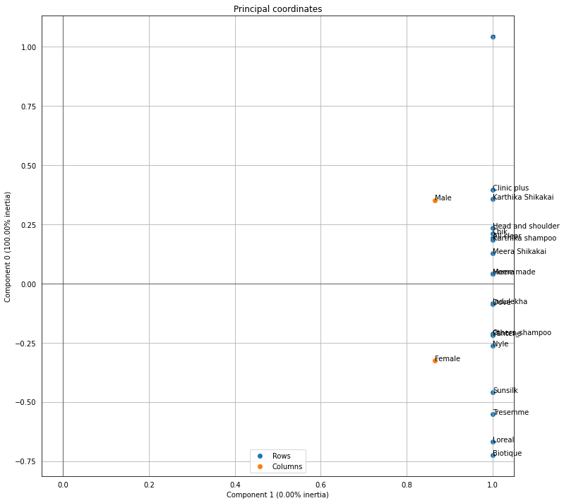

```python
correspondence_analysis('Which is your regular use shampoo1','Gender')
```

```
Eigen values:  [0.09317945323257319, 0.031315967642256255]
Total inertia:  0.1756608847781859
Explained inertia:  [0.5304507793538366, 0.1782751332591783]
It seems Component1 explained around  53 % and Component2 explained about  18 %, so two-dimension feature explained about 71 % of the original dimension.
```

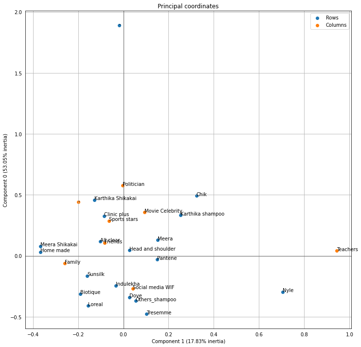

```python
correspondence_analysis('Which is your regular use shampoo1','Which of the following you think influences people the most?')
```

```
Eigen values:  [0.045995784780384116, 0.02060583483092611]
Total inertia:  0.07447946937743496
Explained inertia:  [0.6175632716620757, 0.2766646299063062]
It seems Component1 explained around  62 % and Component2 explained about  28 %, so two-dimension feature explained about 90 % of the original dimension.
```

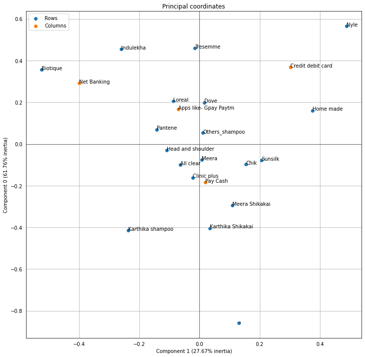

```python
correspondence_analysis('Which is your regular use shampoo1','Which is the most frequently used payment mode for paying Household items  Electricity bills etc')
```

```
Eigen values:  [0.08936091671153154, 0.020976881784973003]
Total inertia:  0.11033779849650462
Explained inertia:  [0.8098848982777411, 0.1901151017222582]
It seems Component1 explained around  81 % and Component2 explained about  19 %, so two-dimension feature explained about 100 % of the original dimension.
```

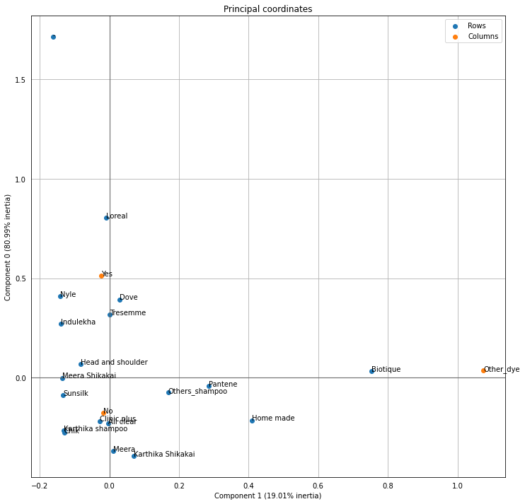

```python
correspondence_analysis('Which is your regular use shampoo1','Do you use hair dye  Hair color1')
```

```
Eigen values:  [0.15383407070454394, 0.12773320822183695]
Total inertia:  0.28156727892638084
Explained inertia:  [0.5463492465854518, 0.45365075341454836]
It seems Component1 explained around  55 % and Component2 explained about  45 %, so two-dimension feature explained about 100 % of the original dimension.
```

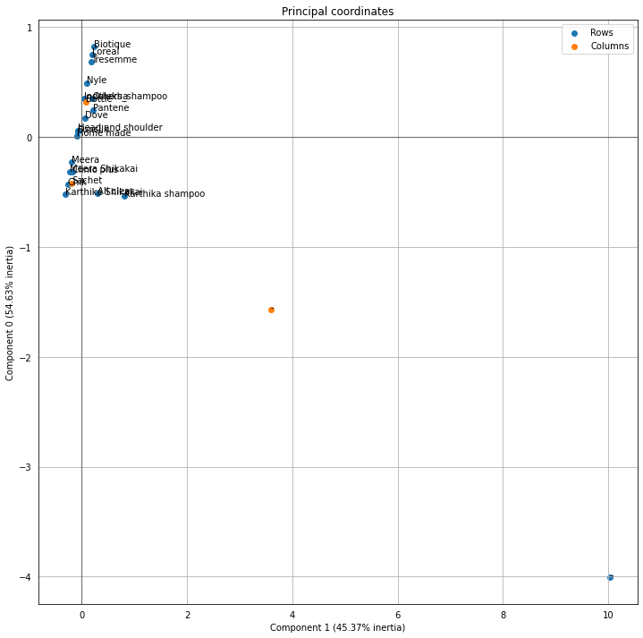

```python
correspondence_analysis('Which is your regular use shampoo1','Which type do you use')
```

```
Eigen values:  [0.04722377156849933, 0.022683063412680598]
Total inertia:  0.10370333441100489
Explained inertia:  [0.4553737045844496, 0.21873031895755027]
It seems Component1 explained around  46 % and Component2 explained about  22 %, so two-dimension feature explained about 68 % of the original dimension.
```

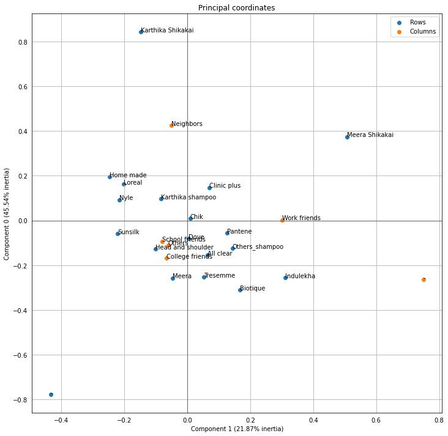

```python
correspondence_analysis('Which is your regular use shampoo1','Who are you still in good touch with ?')
```

### References

- Chi-squared test - https://www.kaggle.com/sohinibhattacharya86/predict-grocery-sales-rf-xgb
- The Search for Categorical Correlation (Cramers, Thiels) - https://towardsdatascience.com/the-search-for-categorical-correlation-a1cf7f1888c9
- Statistical analysis - https://medium.com/analytics-vidhya/statistical-analysis-using-python-e83f10ca3c82